# Predicting Flight Delays

Ella Ashburn

2026-01-15

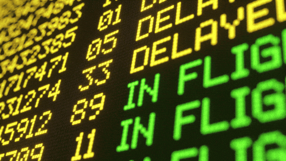

# Introduction

The aim of this project is to build a machine learning model that predicts whether a flight will arrive late using airline, route, and scheduling information available prior to departure. Using U.S. domestic flight data from 2015–2018, this study frames flight delay prediction as a binary classification problem, in which flights are categorized as either delayed or on-time. Classification refers to a modeling approach in which observations are assigned to discrete groups based on their characteristics. The primary goal of this project is predictive rather than causal, meaning the goal is on developing an model that can estimate delay risk before a flight departs, rather than identifying causes of delays. The data set used in this analysis was created by Mu (n.d.) and obtained from Kaggle, with the original data sourced from the United States Department of Transportation. It contains multi-year information on U.S. domestic flights, including flight dates, airline identifiers, origin and destination airports, scheduled departure times, and recorded delay outcomes.

Citation: Mu, Y. (n.d.). Airline Delay and Cancellation Data (2009–2018) [Dataset]. Kaggle. https://www.kaggle.com/datasets/yuanyuwendymu/airline-delay-and-cancellation-data-2009-2018

## What makes a plane delayed?

In this study, a flight is classified as delayed if its total arrival delay is greater than or equal to 15 minutes. Flights with arrival delays less than 15 minutes are classified as on time. This time frame matches the commonly used definition of delay in airline on time performance reporting. Airplane delays are caused by multiple factors, most commonly, severe weather (storms, fog, snow), late-arriving aircraft from previous flights, air traffic control congestion, and crew scheduling constraints.

[figure not shown]

## Why is this model Useful

Almost everybody has experienced a flight delay before, with about 19% of all flights being delayed. Therefore, the ability to anticipate delays can prevent missed connections, additional costs, or many other inconveniences. This classification model can give users insight into whether their plane is at risk of being delayed based on past flights, which will allow people to make more informed decisions about there travels.

# Exploratory Data Analysis

In order to start modeling, our data needs to first be tidied for our specific project. First we need to downsize our data set to our target years of 2015-2018. We will also only keep the predictor variables for a flight delay. Then we will carefully handle the data’s missing values ensuring there removal wont change the integrity of the data.

Before modeling can begin, the data set must first be tidied to align with the goals of this project. The data is first restricted to the target years of 2015–2018. Then only predictor variables available prior to departure are kept, including airline, route, and scheduling information. Additionally, missing values are carefully examined and removed only after verifying that their exclusion does not introduce bias to the data set.

## Load in necessary packages

```r
library(tidyverse)   # data manipulation & visualization
library(data.table)  #  data loading
library(caret)       # modeling framework
library(randomForest)# random forest model
library(pROC)        # ROC curves & AUC
library(readr)
library(dplyr)
```

## Load in and Tidy to 2015-2018 Flight Data only

Since the entire data set is so large we will be testing our model with flight data only from 2015-2018

```r
# single-thread for stability on macOS
data.table::setDTthreads(1)

# Load in data folder
folder <- "/Users/beepbop/Desktop/PSTAT 131/Project/raw_data_files"

# Choose only data from 2015-2018
files <- list.files(folder, pattern = "2015|2016|2017|2018", full.names = TRUE)
```

## Establish variables to keep, predictor variables, and variables used for cleaning

```r
# select variables to keep
keep <- c("FL_DATE","OP_CARRIER","OP_CARRIER_FL_NUM","ORIGIN","DEST","CRS_DEP_TIME","ARR_DELAY","CANCELLED")


# Keep only these variables in data set
df_list <- lapply(files, function(f) {
  read_csv(f, show_col_types = FALSE) %>%
    select(any_of(keep))
})
```

## Remove cancelled flights and create random sample

Since cancelled flights never actually depart, they can’t really be classified as delayed or not delayed. Because of this, we remove those observations from the dataset. We then randomly sample 300,000 flights per year from the remaining data within our time period. This keeps the dataset at a manageable size so the analysis can run efficiently, while still retaining enough observations to maintain reliable results.

```r
# Apply function to:
# remove cancelled flights
# randomly samples 300,000 flights each year

df_list <- lapply(df_list, as.data.table)

set.seed(14)

df_list <- lapply(df_list, function(d) {
  d <- d[CANCELLED != 1]               # remove cancelled flights
  d[sample(.N, min(300000, .N))]       # sample up to 300k per year
})

# combines all data from 2015-2018 into one data set
flight_data_df <- rbindlist(df_list, use.names = TRUE, fill = TRUE)

saveRDS(flight_data_df, "flight_data_df.rds")
```

```r
flight_data_df <- readRDS("flight_data_df.rds")
```

## Data set size and missing variables

```r
nrow(flight_data_df)
```

```
## [1] 1200000
```

```r
any(is.na(flight_data_df))
```

```
## [1] TRUE
```

```r
sum(is.na(flight_data_df))
```

```
## [1] 3133
```

After removing cancelled flights and combining the sampled yearly data sets, the final data set contains approximately 1.2 million observations. Missing values are present, but the total number of missing entries (3,133) is very small relative to the overall data set size. However we must check that this these values are not concentrated to specific airline, airport, or time window before any missing values are removed.

## Check missing values concentrated by Airline

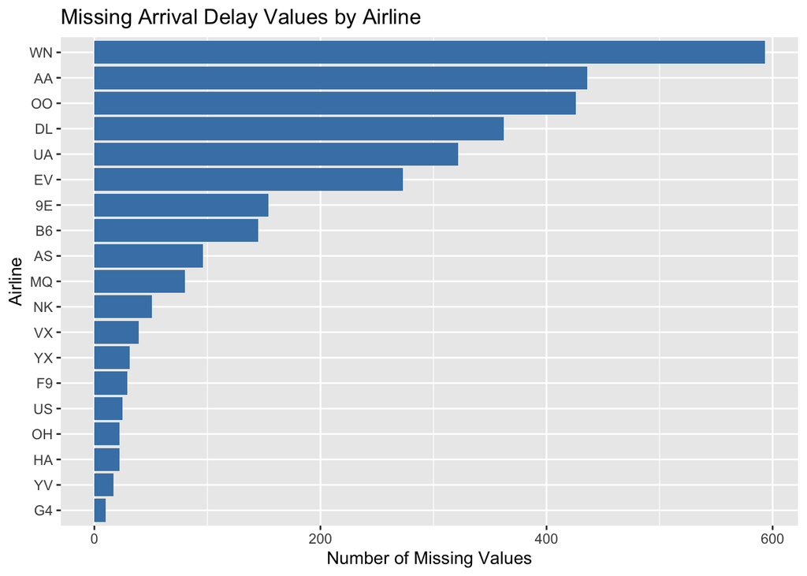

```r
flight_data_df %>%
  filter(is.na(ARR_DELAY)) %>%
  count(OP_CARRIER) %>%
  arrange(desc(n)) %>%
  ggplot(aes(x = reorder(OP_CARRIER, n), y = n)) +
  geom_col(fill = "steelblue") +
  coord_flip() +
  labs(
    title = "Missing Arrival Delay Values by Airline",
    x = "Airline",
    y = "Number of Missing Values"
  )
```

## Check missing values concentrated by origin airport (Top 15)

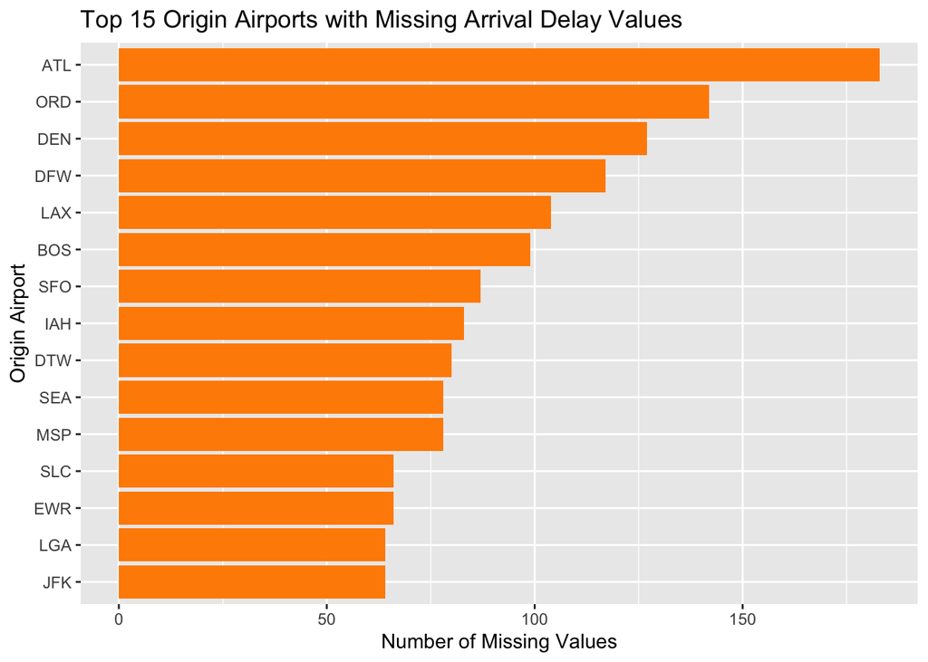

```r
flight_data_df %>%
  filter(is.na(ARR_DELAY)) %>%
  count(ORIGIN) %>%
  arrange(desc(n)) %>%
  slice_head(n = 15) %>%
  ggplot(aes(x = reorder(ORIGIN, n), y = n)) +
  geom_col(fill = "darkorange") +
  coord_flip() +
  labs(
    title = "Top 15 Origin Airports with Missing Arrival Delay Values",
    x = "Origin Airport",
    y = "Number of Missing Values"
  )
```

## Check missing arrival values by Year

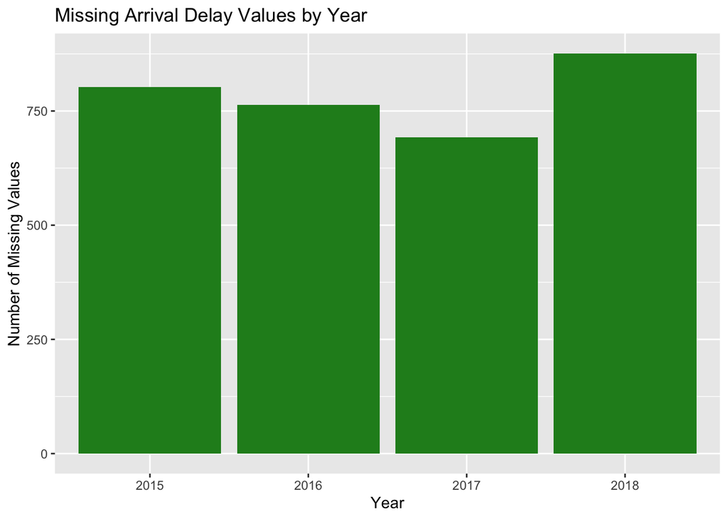

```r
flight_data_df %>%
  mutate(year = substr(FL_DATE, 1, 4)) %>%
  filter(is.na(ARR_DELAY)) %>%
  count(year) %>%
  ggplot(aes(x = year, y = n)) +
  geom_col(fill = "forestgreen") +
  labs(
    title = "Missing Arrival Delay Values by Year",
    x = "Year",
    y = "Number of Missing Values"
  )
```

From these graphs it can be seen that missing values was distributed across many airlines and airports, with higher counts observed primarily for large carriers and major hub airports, which is expected given their higher flight volumes. Missing values were also evenly distributed across years from 2015 to 2018. No strong evidence of concentration within a particular airline, airport, or time period was observed. Because missing values represents a very small fraction of the data set and appears not concentrated any where in the data, observations containing missing predictor values can be removed.

## Remove Missing Values

```r
flight_data_df <- na.omit(flight_data_df)
any(is.na(flight_data_df))
```

```
## [1] FALSE
```

```r
sum(is.na(flight_data_df))
```

```
## [1] 0
```

```r
nrow(flight_data_df)
```

```
## [1] 1196867
```

After removing the missing values the data set now contains 1.19 million rows.

## Creating Response Variable

In order predict if a flight is delayed as a classification model, we must create response variable using the standard 15-minute threshold for arrival delay. In this variable flights with an arrival delay greater than or equal to 15 minutes are classified as delayed, while all others are classified as on-time.

```r
flight_data_df <- flight_data_df %>%
  mutate(delayed = factor(ifelse(ARR_DELAY >= 15, 1, 0),
                          levels = c(0,1),
                          labels = c("Not Delayed","Delayed")))

head(flight_data_df)
```

| FL_DATE | OP_CARRIER | OP_CARRIER_FL_NUM | ORIGIN | DEST | CRS_DEP_TIME | ARR_DELAY | CANCELLED | delayed |
| --- | --- | --- | --- | --- | --- | --- | --- | --- |
| 2015-02-08 | DL | 2355 | ATL | LAX | 2152 | -19 | 0 | Not Delayed |
| 2015-02-17 | DL | 2399 | ATL | RIC | 1205 | 53 | 0 | Delayed |
| 2015-06-28 | DL | 503 | PDX | ATL | 2225 | -7 | 0 | Not Delayed |
| 2015-11-18 | DL | 2624 | IND | MSP | 1609 | -1 | 0 | Not Delayed |
| 2015-11-27 | OO | 5171 | CLT | ORD | 1726 | -9 | 0 | Not Delayed |
| 2015-04-19 | WN | 1161 | MKE | MSP | 1625 | -17 | 0 | Not Delayed |

# Codebook

Now that we have cleaned and tidied our data set, only the variables relevant to predicting if a flight will be delayed were kept. These are all the variables we will use in our analysis:

**FL_DATE**  
Scheduled calendar date of the flight (YYYY-MM-DD format). This variable is used to extract year-level information and temporal patterns.

**OP_CARRIER**  
Two-letter airline carrier code identifying the operating airline (e.g., DL = Delta, WN = Southwest). This variable serves as a categorical predictor.

**OP_CARRIER_FL_NUM**  
Flight number assigned by the operating carrier. Although numeric, it functions as an identifier rather than a continuous variable.

**ORIGIN**  
Three-letter IATA airport code representing the departure airport (e.g., ATL = Atlanta, LAX = Los Angeles). This variable captures route-level information.

**DEST**  
Three-letter IATA airport code representing the destination airport. Used to identify route patterns and travel demand characteristics.

**CRS_DEP_TIME**  
Scheduled departure time in 24-hour HHMM format (e.g., 2152 = 9:52 PM). This variable is available prior to departure and may capture time-of-day effects.

**ARR_DELAY**  
Arrival delay in minutes. Positive values indicate late arrivals, while negative values indicate early arrivals. This variable is used to construct the binary response variable.

**CANCELLED**  
Indicator variable equal to 1 if the flight was cancelled and 0 otherwise. Cancelled flights were removed during data cleaning since arrival delay is undefined for cancelled flights.

**DELAYED**  
Binary indicator equal to 1 if ARR_DELAY ≥ 15 minutes and 0 otherwise. This variable serves as the response variable in the classification model.

# Visual EDA

Our data is almost ready to model, but before we do so lets visualize how some of the predictor variables effect the chance of a flight being delayed.

## Number of Flights Delayed vs. Not Delayed in data set

First lets see how our data set is distributed between delayed and no delayed flights

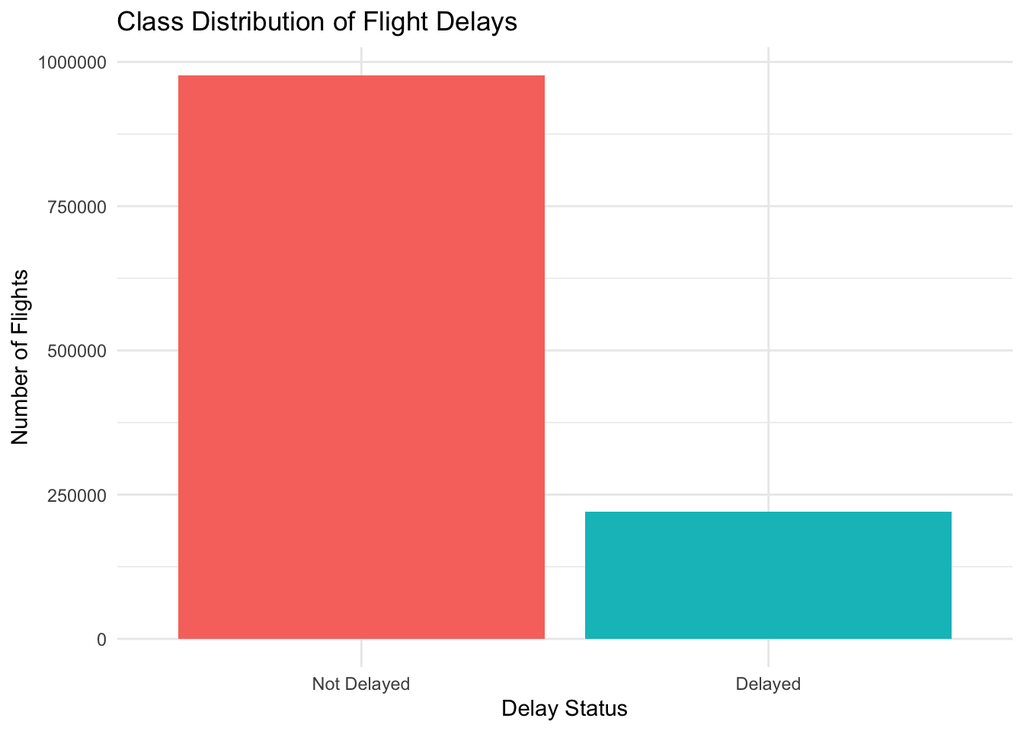

```r
flight_data_df %>%
  count(delayed) %>%
  ggplot(aes(x = delayed, y = n, fill = delayed)) +
  geom_col() +
  labs(
    title = "Class Distribution of Flight Delays",
    x = "Delay Status",
    y = "Number of Flights"
  ) +
  theme_minimal() +
  theme(legend.position = "none")
```

```r
count_delayed <- sum(flight_data_df$delayed == "Delayed")
count_not_delayed <- sum(flight_data_df$delayed == "Not Delayed")
proportion_delayed <- signif(count_delayed /(count_delayed + count_not_delayed) *100, digits =2)
proportion_not_delayed <- signif(count_not_delayed /(count_delayed + count_not_delayed) *100, digits=2)
```

This graph shows that the majority of flights within the data set are not delayed, more specifically the proportion of delayed flight is 18% compared to the proportion of not delayed flight 82%. Because the proportion of non-delayed flights is much larger, this imbalance may affect the model’s ability to accurately predict delayed flights.

## Delay Rate by Airline

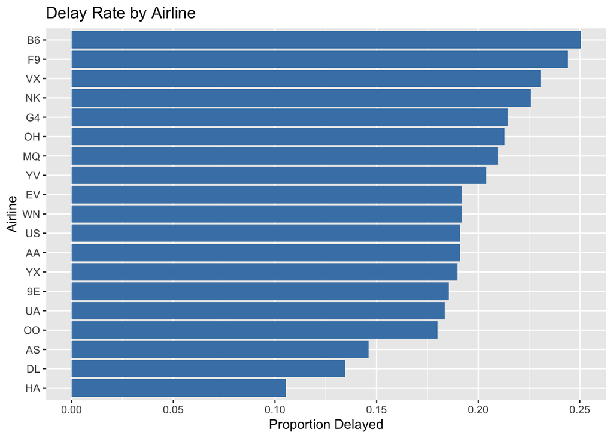

```r
flight_data_df %>%
  group_by(OP_CARRIER) %>%
  summarise(
    delay_rate = mean(delayed == "Delayed", na.rm = TRUE),
    n = n()
  ) %>%
  arrange(desc(delay_rate)) %>%
  ggplot(aes(x = reorder(OP_CARRIER, delay_rate),
             y = delay_rate)) +
  geom_col(fill = "steelblue") +
  coord_flip() +
  labs(
    title = "Delay Rate by Airline",
    x = "Airline",
    y = "Proportion Delayed"
  )
```

The delay rate varies considerably across airlines, with proportions ranging from approximately 10% to 25%. This suggests that airline identity may be an important predictor of delay risk. Delays vary across airlines because of differences in operations, scheduling, and common flight paths.

## Delay Rate by Hour of Departure

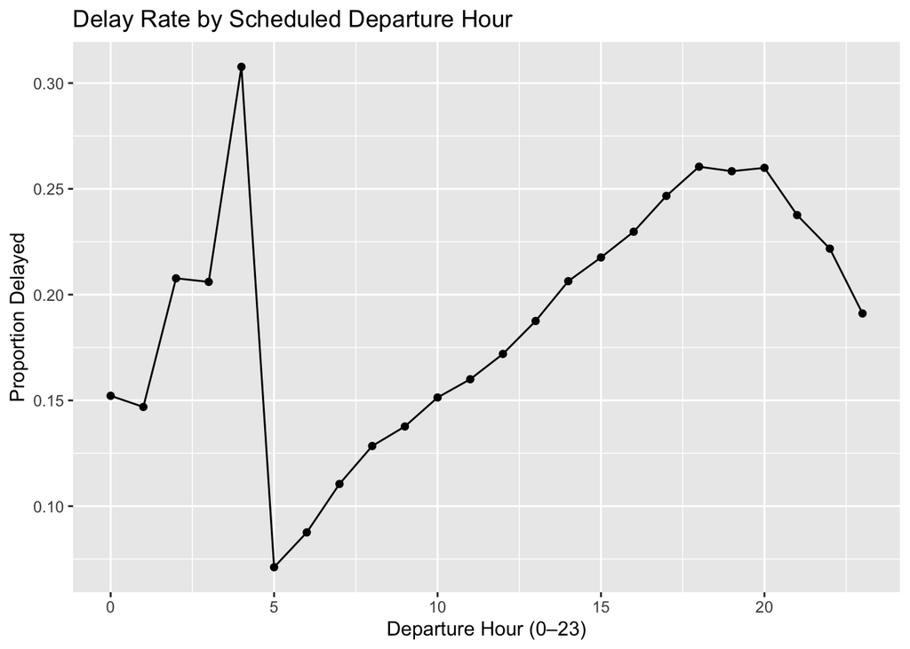

```r
flight_data_df <- flight_data_df %>%
  mutate(
    CRS_DEP_TIME = as.numeric(CRS_DEP_TIME),
    dep_hour = floor(CRS_DEP_TIME / 100)
  )

flight_data_df %>%
  filter(!is.na(dep_hour), dep_hour >= 0, dep_hour <= 23) %>%
  group_by(dep_hour) %>%
  summarise(delay_rate = mean(delayed == "Delayed", na.rm = TRUE)) %>%
  ggplot(aes(x = dep_hour, y = delay_rate)) +
  geom_line() +
  geom_point() +
  labs(
    title = "Delay Rate by Scheduled Departure Hour",
    x = "Departure Hour (0–23)",
    y = "Proportion Delayed"
  )
```

## Delay Rate by Origin × Destination (For top 15 routes only)

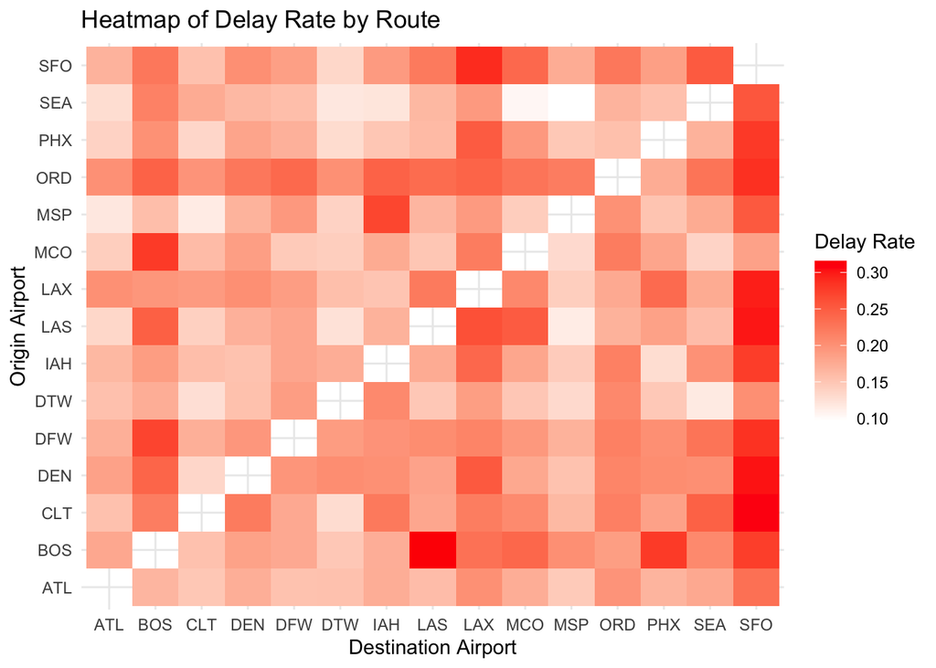

```r
top_origins <- flight_data_df %>%
  count(ORIGIN, sort = TRUE) %>%
  slice_head(n = 15) %>%
  pull(ORIGIN)

top_dests <- flight_data_df %>%
  count(DEST, sort = TRUE) %>%
  slice_head(n = 15) %>%
  pull(DEST)

route_summary <- flight_data_df %>%
  filter(ORIGIN %in% top_origins,
         DEST %in% top_dests) %>%
  group_by(ORIGIN, DEST) %>%
  summarise(
    delay_rate = mean(delayed == "Delayed", na.rm = TRUE),
    n = n(),
    .groups = "drop"
  )

ggplot(route_summary, aes(x = DEST, y = ORIGIN, fill = delay_rate)) +
  geom_tile() +
  scale_fill_gradient(low = "white", high = "red") +
  labs(
    title = "Heatmap of Delay Rate by Route",
    x = "Destination Airport",
    y = "Origin Airport",
    fill = "Delay Rate"
  ) +
  theme_minimal()
```

The heat map shows a lot of variation in delay rates across different routes. This means that certain origin–destination pairs have consistently higher delay probabilities, suggesting that route-level characteristics may contribute meaningfully to predictive performance.

# Setting up our Model

Now it is time to model our to see if we can predict if a flight is going to be delayed based of our predictors. The first step of this process is to split our data into training and testing. since the data set is very large we will split the data 70% training and 30% testing.

## Split Data into Testing and Training

Before we do any model building, we first split the data into training and testing sets. For this dataset, I used a 70/30 split, where 70% of the data is used to train the models and the remaining 30% is reserved for testing. This allows the models to learn from a large portion of the data while still leaving a substantial amount of observations to evaluate how well the models perform on new, unseen data. The testing set acts as a final check on the model’s performance and helps prevent overfitting, where a model performs well on the training data but poorly on new data. A random seed is also set so that the split remains consistent each time the code is run.

```r
set.seed(14)

# Create Train index
train_index <- createDataPartition(
  flight_data_df$delayed,
  p = 0.7,
  list = FALSE
)

test_data <- flight_data_df[-train_index, ] # keep other 30% of the rows
train_data <- flight_data_df[train_index, ]
```

## Stratify data on the Outcome Variable

Now that the data is split we need to stratify on the outcome variable, delayed.

```r
prop.table(table(train_data$delayed))
```

```
##
## Not Delayed     Delayed
##    0.816256    0.183744
```

```r
prop.table(table(test_data$delayed))
```

```
##
## Not Delayed     Delayed
##   0.8162563   0.1837437
```

The stratification worked because both training and testing sets have very similar Delayed and Not Delayed percentages.

## Recipe Specification

The first step in to set up the model appropriately is to remove the variables ARR_DELAY and CANCELLED. ARR_DELAY must be removed because it was used to create the variable delayed (the outcome variable). Flight number was also excluded because it functions primarily as an identifier rather than a meaningful predictor. For computational feasibility, origin and destination airports outside the top 30 most common categories were grouped as “OTHER” when needed for specific models. CANCELLED is removed because all cancelled flights have already been removed so this variable is unnecessary. Then we will make sure all categorical variables are factors.

```r
train_data <- train_data |>
  select(-ARR_DELAY, -CANCELLED)

test_data <- test_data |>
  select(-ARR_DELAY, -CANCELLED)
```

Now we must consider that our dummy matrix will be to large and will crash. To reduce the amount we will keep only the top 30 ORIGIN an DEST airports and group the rest as “OTHER”. We will also drop flight number from dummy encoding because it is just an identifier and generally a bad predictor. For example if there is schedule or aircraft changes the ML model will not be about to generalize.

```r
#Remove OP_CARRIER_FL_NUM from Training and Testing Data
train_data <- train_data %>% select(-OP_CARRIER_FL_NUM)
test_data  <- test_data %>% select(-OP_CARRIER_FL_NUM)


# keep just the top 30 most mentioned airports
top_airports <- train_data %>%
  count(ORIGIN, sort = TRUE) %>%
  slice_head(n = 30) %>%
  pull(ORIGIN)

#Classify not top 30 airports as "OTHER"

train_data <- train_data |>
  mutate(
    ORIGIN = ifelse(ORIGIN %in% top_airports, ORIGIN, "OTHER"),
    DEST   = ifelse(DEST %in% top_airports, DEST,   "OTHER")
  )

test_data <- test_data %>%
  mutate(
    ORIGIN = ifelse(ORIGIN %in% top_airports, ORIGIN, "OTHER"),
    DEST   = ifelse(DEST   %in% top_airports, DEST,   "OTHER")
  )
```

## Transform Categorical Variables into Factors

```r
# Turn outcome variable into factor
train_data$delayed <- factor(train_data$delayed, levels = c("Not Delayed", "Delayed"))
test_data$delayed  <- factor(test_data$delayed,  levels = c("Not Delayed", "Delayed"))

# convert categorical variables to factors
train_x <- train_data |>
  mutate(OP_CARRIER = factor(OP_CARRIER),
         ORIGIN = factor(ORIGIN),
         DEST = factor(DEST)) |>
  select(-delayed)

test_x <- test_data |>
  mutate(OP_CARRIER = factor(OP_CARRIER),
         ORIGIN = factor(ORIGIN),
         DEST = factor(DEST)) |>
  select(-delayed)
```

## Dummy Encoding Variables

Some of the predictor variables in the dataset are categorical, such as airline carrier, origin airport, and destination airport. Since many machine learning models require numerical inputs, these categorical variables need to be converted into a numeric format. To accomplish this, dummy (one-hot) encoding is used, which creates separate binary indicator variables for each category. This allows the models to incorporate categorical information without incorrectly implying any numerical ordering between categories.

```r
dummies <- dummyVars(~ ., data = train_x, fullRank = TRUE)

train_processed <- as.data.frame(predict(dummies, newdata = train_x))
test_processed  <- as.data.frame(predict(dummies, newdata = test_x))

# Add outcome back
train_processed$delayed <- train_data$delayed
test_processed$delayed  <- test_data$delayed
```

## Center and Scale features

Numeric predictor variables are centered and scaled before modeling. Centering subtracts the mean from each feature, and scaling divides by the standard deviation. This ensures that predictors are on a similar scale, which can improve performance of certain models.

```r
preproc <- preProcess(train_processed[, -which(names(train_processed) == "delayed")],
                      method = c("center", "scale"))

train_processed[, -which(names(train_processed) == "delayed")] <-
  predict(preproc, train_processed[, -which(names(train_processed) == "delayed")])

test_processed[, -which(names(test_processed) == "delayed")] <-
  predict(preproc, test_processed[, -which(names(test_processed) == "delayed")])
```

## K-Fold Cross Validation

In this step we will set the rules for model training used 5-fold cross-validation on the training set. Because the outcome variable is a factor, we will resample in caret is stratified, meaning each fold preserves the proportion of delayed and non-delayed flights. Performance will then be summarized using ROC/AUC (with class probabilities enabled), and predictions from cross-validation will be saved for later evaluation.

```r
set.seed(14)

# Use a 5-fold CV
ctrl <- trainControl(  # set rules for training
  method = "cv", # cross validation
  number = 5, # 5 fold cross validation
  classProbs = TRUE,  # compute probabilities for classes
  summaryFunction = twoClassSummary,
  savePredictions = "final" # save predictions made during cross-validation
)

train_data$delayed <- relevel(train_data$delayed, ref = "Delayed")
test_data$delayed  <- relevel(test_data$delayed,  ref = "Delayed")
```

# Fit model Types

Now it is finally time to fit and evaluate our models in order to find the one that is best at predicting flight delays from our data. Because the response variable indicates whether a flight was delayed or not, classification models were appropriate for this problem. The models tested include logistic regression, random forest, linear discriminant analysis (LDA), and a CART decision tree. Each model was trained using the same predictors so their performance could be compared consistently.

## 1. Logistic Regression

**Preparing Data for the Logistic Regression Model**

```r
train_lr <- train_data |>
  mutate(
    # CRS_DEP_TIME is formatted like 1325 (1:25 PM)
    # Convert to numeric hour: 1325 -> 13
    dep_hour = floor(as.numeric(CRS_DEP_TIME) / 100),
    # Extract year from date (YYYY-MM-DD)
    year = as.integer(substr(FL_DATE, 1, 4)),
    # Extract month from date (YYYY-MM-DD)
    month = as.integer(substr(FL_DATE, 6, 7))
  ) |>
   # Keep only outcome + predictors for this baseline    model
  select(delayed, OP_CARRIER, ORIGIN, DEST, dep_hour, year, month) |>
  # Remove rows where dep_hour is missing
  filter(!is.na(dep_hour), dep_hour >= 0, dep_hour <= 23)

test_lr <- test_data |>
  mutate(
    dep_hour = floor(as.numeric(CRS_DEP_TIME) / 100),
    year = as.integer(substr(FL_DATE, 1, 4)),
    month = as.integer(substr(FL_DATE, 6, 7))
  ) |>
  select(delayed, OP_CARRIER, ORIGIN, DEST, dep_hour, year, month) |>
  filter(!is.na(dep_hour), dep_hour >= 0, dep_hour <= 23)


set.seed(14)
# Fix Not Delayed to NotDelayed becuse speces are not allowed in the fit

train_lr$delayed <- factor(train_lr$delayed,
                           levels = c("Not Delayed", "Delayed"),
                           labels = c("NotDelayed", "Delayed"))

test_lr$delayed <- factor(test_lr$delayed,
                          levels = c("Not Delayed", "Delayed"),
                          labels = c("NotDelayed", "Delayed"))
```

*Fit Logisitc Regression*

```r
logit_fit <- train(
  delayed ~ ., #predict this variable (delayed) using all other columns
  data = train_lr,
  method = "glm",  # model is generalized linear model
  family = binomial(), # logistic regression
  metric = "ROC",
  trControl = ctrl # cross validation we created
)

logit_fit
```

```
## Generalized Linear Model
##
## 837807 samples
##      6 predictor
##      2 classes: 'NotDelayed', 'Delayed'
##
## No pre-processing
## Resampling: Cross-Validated (5 fold)
## Summary of sample sizes: 670245, 670246, 670246, 670246, 670245
## Resampling results:
##
##   ROC        Sens       Spec
##   0.6334053  0.9999006  0.0004092453
```

The model achieved an ROC value of about 0.63, which suggests it performs slightly better than random guessing but is still relatively weak at predicting delays. The model shows extremely high sensitivity but very low specificity, meaning it predicts most flights as not delayed. This behavior is likely due to the strong class imbalance in the data set, where roughly 82% of flights are not delayed.

## 2. Random Forest

For this model we will need to randomly sample 100,000 rows because keeping all the rows will cause the random forest model to fail from memory exhaustion.

```r
# Convert variables to factors
train_rf <- train_lr %>%
  mutate(
    OP_CARRIER = factor(OP_CARRIER),
    ORIGIN = factor(ORIGIN),
    DEST = factor(DEST),
    delayed = factor(delayed, levels = c("NotDelayed", "Delayed"))
  )

test_rf <- test_lr %>%
  mutate(
    OP_CARRIER = factor(OP_CARRIER, levels = levels(train_rf$OP_CARRIER)),
    ORIGIN = factor(ORIGIN, levels = levels(train_rf$ORIGIN)),
    DEST = factor(DEST, levels = levels(train_rf$DEST)),
    delayed = factor(delayed, levels = c("NotDelayed", "Delayed"))
  )

# Create a smaller stratified sample for random forest
set.seed(14)

rf_index <- createDataPartition(
  train_rf$delayed,
  p = 100000 / nrow(train_rf),
  list = FALSE
)

train_rf_small <- train_rf[rf_index, ]

# Check class balance
prop.table(table(train_rf_small$delayed))
```

```
##
## NotDelayed    Delayed
##  0.8162518  0.1837482
```

*Fit the model on the sample*

```r
set.seed(14)

rf_fit <- train(
  delayed ~ .,
  data = train_rf_small,
  method = "rf",
  metric = "ROC",
  trControl = ctrl,
  ntree = 100,
  tuneLength = 2
)

rf_fit
```

```
## Random Forest
##
## 100001 samples
##      6 predictor
##      2 classes: 'NotDelayed', 'Delayed'
##
## No pre-processing
## Resampling: Cross-Validated (5 fold)
## Summary of sample sizes: 80001, 80000, 80001, 80001, 80001
## Resampling results across tuning parameters:
##
##   mtry  ROC        Sens       Spec
##    2    0.5225394  1.0000000  0.000
##   81    0.6034864  0.9214466  0.136
##
## ROC was used to select the optimal model using the largest value.
## The final value used for the model was mtry = 81.
```

The random forest performed slightly worse than the logistic regression model. The best version of the model acheived a cross-validated ROC of about 0.60. One difference compared to logistic regression model is that the random forest predicted more flights as delayed, which increased the specificity to around 0.14. However, the overall predictive performance was still fairly limited. This suggests that even with a more flexible model that can capture nonlinear relationships, the available predictors do not contain enough information to accurately identify delayed flights.

## 3. LDA (Linear Discriminant Analysis)

*Fit the model*

```r
set.seed(14)

lda_fit <- train(
  delayed ~ .,
  data = train_lr,
  method = "lda",
  metric = "ROC",
  trControl = ctrl
)

lda_fit
```

```
## Linear Discriminant Analysis
##
## 837807 samples
##      6 predictor
##      2 classes: 'NotDelayed', 'Delayed'
##
## No pre-processing
## Resampling: Cross-Validated (5 fold)
## Summary of sample sizes: 670245, 670246, 670246, 670246, 670245
## Resampling results:
##
##   ROC        Sens       Spec
##   0.6332221  0.9996783  0.001065336
```

The LDA model performed very similarly to the logistic regression model, with a cross-validated ROC of about 0.63. The model predicted almost all flights as not delayed, leading to extremely high sensitivity but very low specificity. This indicates that while the model can easily identify flights that are not delayed, it struggles to correctly identify delayed flights

## 4. Pruned Decision Tree (CART)

*Fit model*

```r
set.seed(14)

tree_fit <- train(
  delayed ~ .,
  data = train_lr,
  method = "rpart",
  metric = "ROC",
  trControl = ctrl,
  tuneLength = 5
)

tree_fit
```

```
## CART
##
## 837807 samples
##      6 predictor
##      2 classes: 'NotDelayed', 'Delayed'
##
## No pre-processing
## Resampling: Cross-Validated (5 fold)
## Summary of sample sizes: 670245, 670246, 670246, 670246, 670245
## Resampling results across tuning parameters:
##
##   cp            ROC        Sens       Spec
##   4.547167e-05  0.5422618  0.9996315  0.0017344420
##   4.871965e-05  0.5422622  0.9996242  0.0017539301
##   5.629826e-05  0.5210388  0.9997850  0.0009484215
##   5.846358e-05  0.5210388  0.9997850  0.0009484215
##   6.850278e-05  0.5000000  1.0000000  0.0000000000
##
## ROC was used to select the optimal model using the largest value.
## The final value used for the model was cp = 4.871965e-05.
```

*Decision Tree Plot*

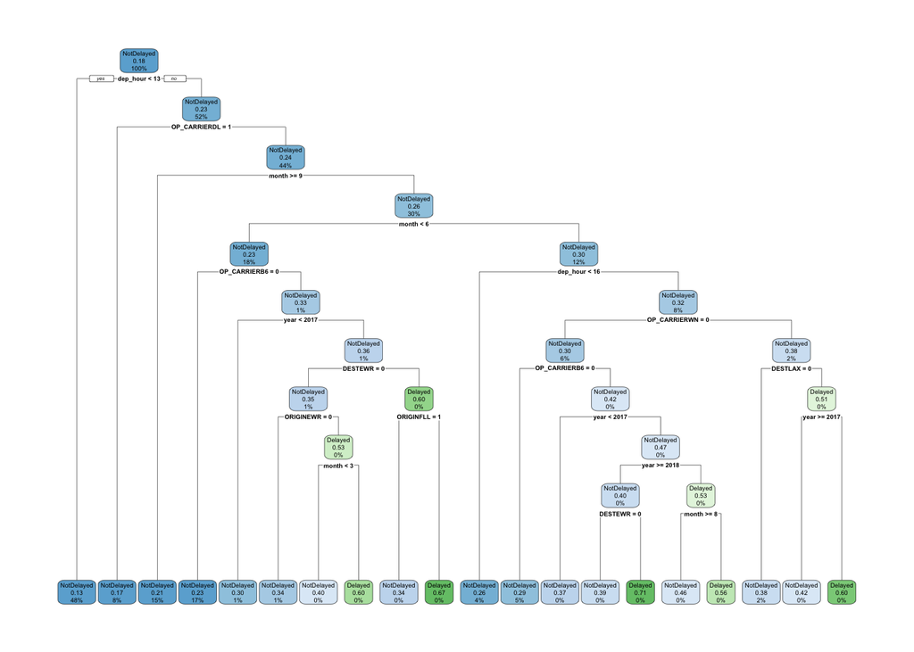

```r
library(rpart.plot)

rpart.plot(tree_fit$finalModel)
```

The CART decision tree performed the worst out of the models tested, with a cross-validated ROC of about 0.54. Like the other models, it predicted nearly all flights as not delayed, resulting in extremely high sensitivity but very low specificity. This indicates that the decision tree was not able to effectively separate delayed and non-delayed flights using the available predictors.

# The Winner is Logistic Regression!

## Evaluate Logistic Regression on Test Data

[figure not shown]

```r
# Class probabilities
logit_prob <- predict(logit_fit, newdata = test_lr, type = "prob")
#Gives probabilities. for each class

# Class predictions (default threshold = 0.5)
logit_pred <- predict(logit_fit, newdata = test_lr)

# Confusion matrix (Compares predicted class to actual classes)
confusionMatrix(logit_pred, test_lr$delayed)
```

```
## Confusion Matrix and Statistics
##
##             Reference
## Prediction   NotDelayed Delayed
##   NotDelayed     293049   65951
##   Delayed            36      24
##
##                Accuracy : 0.8162
##                  95% CI : (0.815, 0.8175)
##     No Information Rate : 0.8163
##     P-Value [Acc > NIR] : 0.5217
##
##                   Kappa : 4e-04
##
##  Mcnemar's Test P-Value : <2e-16
##
##             Sensitivity : 0.9998772
##             Specificity : 0.0003638
##          Pos Pred Value : 0.8162925
##          Neg Pred Value : 0.4000000
##              Prevalence : 0.8162563
##          Detection Rate : 0.8161561
##    Detection Prevalence : 0.9998329
##       Balanced Accuracy : 0.5001205
##
##        'Positive' Class : NotDelayed
##
```

```r
# AUC
roc_obj <- roc(response = test_lr$delayed,
                     predictor = logit_prob[,"Delayed"])
auc(roc_obj)
```

```
## Area under the curve: 0.6357
```

## ROC Curve

Let’s take a look at the ROC curve

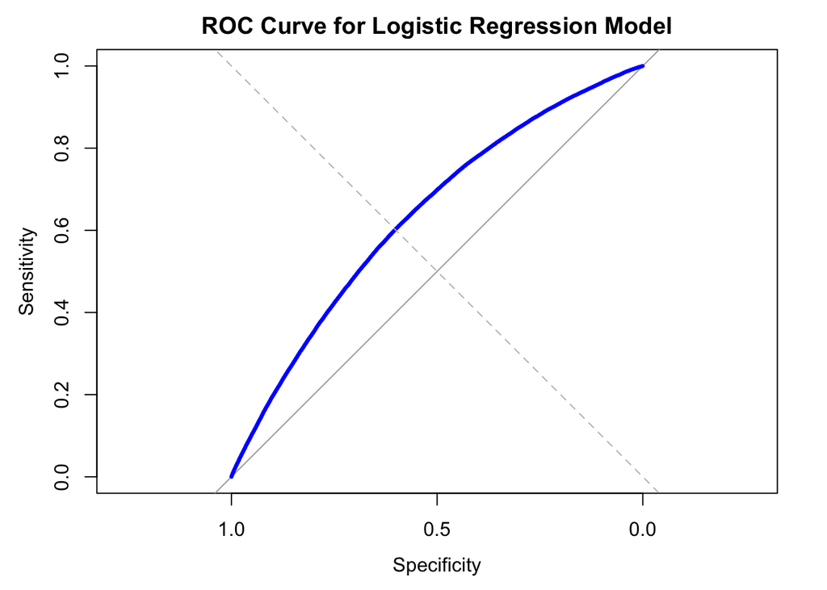

```r
plot(roc_obj, col="blue", lwd=3,
     main="ROC Curve for Logistic Regression Model")
abline(a=0,b=1,lty=2,col="gray")
```

## Model Comparison Table

| Model | ROC |
| --- | --- |
| Logistic Regression | 0.633 |
| Random Forest | 0.603 |
| LDA | 0.633 |
| CART Decision Tree | 0.542 |

This Table compares the cross-validated ROC values across all four classification models. Logistic regression and LDA performed best, both achieving ROC values of approximately 0.63, while random forest and CART performed slightly worse.

The logistic regression model was selected as the final model based on its cross-validated ROC performance. After evaluating this model on the testing data set the resulting ROC AUC was found to be 0.63. This means the model has modest ability to distinguish between delayed and non-delayed flights. The confusion matrix shows that the model correctly identifies most non-delayed flights but struggles to correctly classify delayed flights, which is likely due to the strong class imbalance present in the data set.

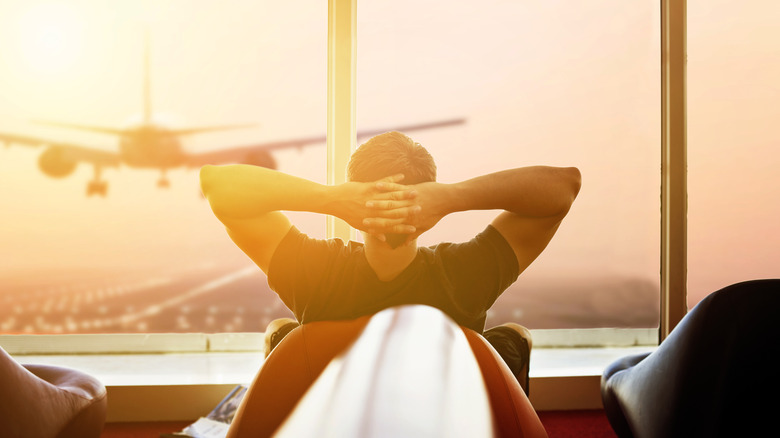

# Conclusion

This project explored whether flight delays can be predicted using information known before departure, including airline carrier, origin and destination airports, scheduled departure time, and date-related variables. To answer this question, several classification models were fit and compared, including logistic regression, random forest, linear discriminant analysis (LDA), and a pruned decision tree (CART). Across the models tested, logistic regression performed best overall, with LDA producing very similar results. Although the best model performed better than random guessing, the overall predictive power remained modest. This suggests that while these pre-departure variables do contain some useful information, they are not strong enough on their own to predict flight delays with high accuracy.

A major pattern observed across all models was the difficulty of correctly identifying delayed flights. Because the dataset was highly imbalanced, with most flights labeled as not delayed, many of the models tended to predict nearly all flights as on time. As a result, overall accuracy appeared relatively high, but specificity remained very low. This shows that predicting flight delays is more challenging than it may first appear, especially when only limited scheduling and route information is available. In the future, this analysis could likely be improved by including additional predictors such as weather conditions, airport congestion, air traffic control delays, or information about late-arriving aircraft. This project was personally interesting to me because I have experienced the frustration of flight delays myself, and it was fascinating to see how machine learning can be used to study events that travelers often wish they could know in advance.  
Thank you so much for reading

[figure not shown]